# Volpe R Course: Session 4, Communicating Results

Instructors: Don Fisher, Dan Flynn, Jessie Yang  
Course webpage: http://bit.ly/volpeR

9/26/2017

# Overview

### Last session:

- Data exploration
  - Aggregation
  - Merging and Matching

### Today: Communicating results

- Regular expression review
- Basic graphics
- `ggplot2` package
- Basic analysis

# Homework review

*We will review example solutions to the homework assignments here*

### Make summary tables using `aggregate` and other functions

```r
aggregate(hub$tripduration,
          by = list(hub$usertype, hub$bikeid), FUN = mean)

tapply (hub$bikeid, hub$tripduration, mean)
```

### Make a subset using `grep`

```r
Kendall.stations <- grep("Kendall" , hub$start.station.name)
merge1.kendall <- hub[Kendall.stations,]
```

### Use `merge`

```r
track1 <- read.csv("Homework 3 1 MUI.csv") # first dataset
track2 <- read.csv("Homework 3 2 MUI.csv") # second dataset

names (track1) # check header for both dataset
merge (track1, track2, by.x ="ft1", by.y = "ft2", all = T) # merge two data frames by track disatance

# Match two track geometry dataset
t1 <- match (track1$MP1, track2$MP2) # combined two dataset

t2 <- data.frame (track1, track2[t1,])
```

# Regular expressions

Quick digression to review material from last session!

The use of `sub` last session is an example of *regular expression*. These are very flexible and form the basis for all search engines. In R, there are number of ways to use regular expressions, with `grep` and `sub` being two of the most common ones. `regexpr` also provides additional options for those familiar with Perl or Python.

```r
text1 <- c("Testing", "matching ", " and substitutions")

grep("testing", text1, ignore.case = TRUE) # Pattern matching

sub(" +$", "", text1) # find and replace trailing whitespace
grep("^ ", text1) # find elements which start with a whitespace
grep("^[A-Z]", text1) # find elements which start with a capital letter
```

# Basic graphics

You have already seen the power of `plot()` in examples. We have used it to make scatterplots, but also to make diagnostic plots of linear models. When in doubt, you can always try to `plot()` an object and R will make a guess about what kind of plot you want.

Example:

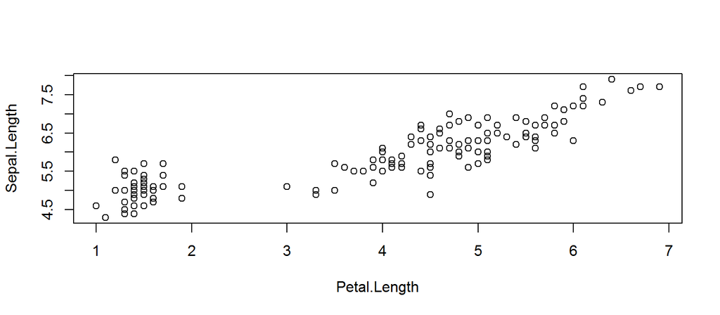

```r
data(iris) # see ?iris

# Formula (y ~ x) versus (x, y) specification
plot(Sepal.Length ~ Petal.Length, data = iris)
```

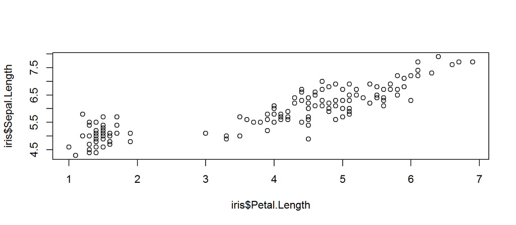

```r
plot(iris$Petal.Length, iris$Sepal.Length) # identical
```

```r
# plot(Petal.Length, Sepal.Length, data = iris) # fails
```

# Basic graphics (plus some analysis)

You frequently want to analyze what the trend of the data is statistically, not just graphically. We can use a simple linear model and plot the result using `lm()`:

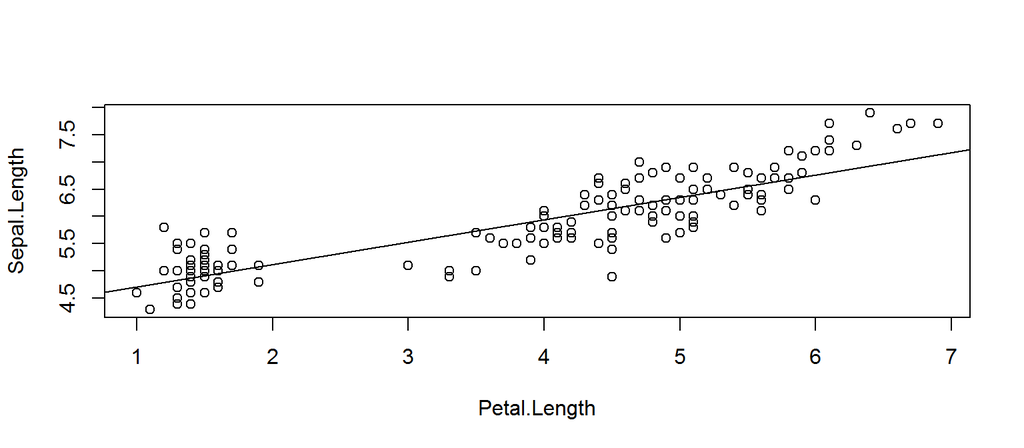

```r
plot(Sepal.Length  ~ Petal.Length, data = iris)

summary(linmod <- lm(Sepal.Length ~ Petal.Length, data = iris))

abline(linmod)
```

### Interpretation:

What is the slope of this line? How would you interpret it?

# Basic graphics (plus some analysis)

We have often looked at boxplots for categorical data. The analysis that corresponds to a simple boxplot is an “Analysis of Variance” or ANOVA. In `R`, you can do this analysis with the `aov` function:

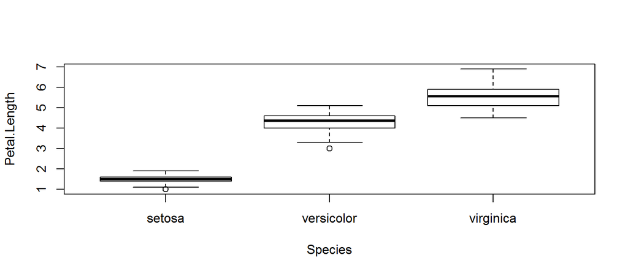

```r
plot(Petal.Length ~ Species,
     data = iris)
```

```r
summary(aovmod <- aov(Petal.Length ~ Species, data = iris))
coef(aovmod)
```

### Interpretation:

What is the model estimate for the mean value of *Iris versicolor* petal lengths?

# Basic graphics

Back to graphics! The power of the base graphics package in R is control of each element of the plot. The challenge is knowing how to exercise that control.

`par()` sets graphics parameters and contains much of what you want to do. Highlights from `par`:

```
mfrow - matrix format. Set to c(1, 2) for two panel figure, adjacent
pch   - plotting character.
lty   - line type. Try lty = 2 or lty = 3
cex   - character expansion. Very useful for making symbols more visible
mar   - margins. Set to mar = rep(1, 4) for narrow margins all around.
col   - colors, see colors() for full list or
www.nceas.ucsb.edu/~frazier/RSpatialGuides/colorPaletteCheatsheet.pdf)
```

`?par` for the full list.

# Basic graphics

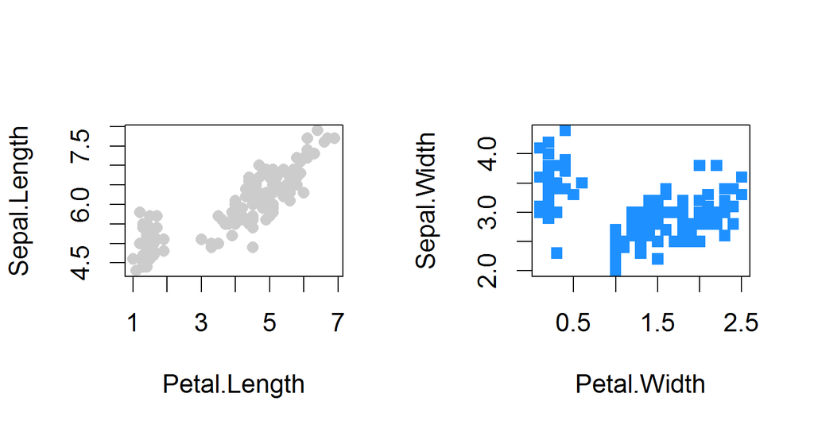

```r
par(mfrow = c(1, 2),
    pch = 16,
    cex = 1.5) # makes everything bigger

plot(Sepal.Length ~ Petal.Length,
     col = "grey80",
          data = iris)

plot(Sepal.Width ~ Petal.Width,
     col = "dodgerblue",
     pch = 15, # can override par settings
          data = iris)
```

# Basic graphics

`barplot()` can be used to create a bar chart, but it is a bit clunky to add error bars. Basic workflow:

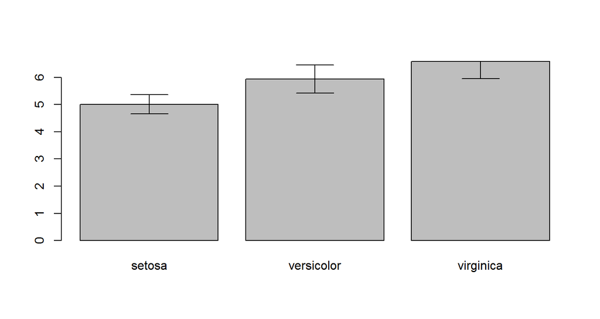

```r
means <- tapply(iris$Sepal.Length, iris$Species, mean)
sds <-  tapply(iris$Sepal.Length, iris$Species, sd)

# save the location of the bars as 'bp'
bp <- barplot(means)

arrows(bp, means+sds, # see ?arrows
       bp, means-sds,
       angle = 90,
       code = 3)
```

# Basic graphics

Improve a graphic by ensuring that there are clear labels (`arrows` code not shown).

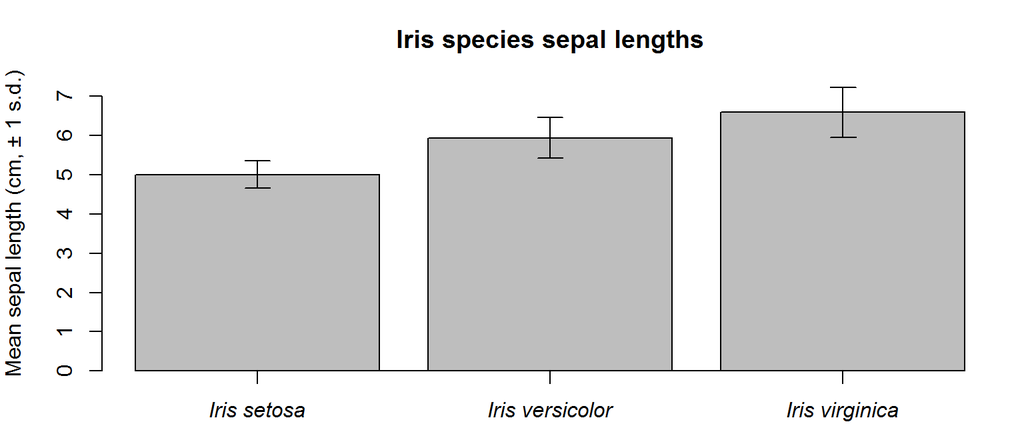

```r
par(mar = c(3, 4, 3, 1)) # Narrowing margins
bp <- barplot(means,
              ylab = "Mean sepal length (cm, ? 1 s.d.)",
              main = "Iris species sepal lengths",
              xaxt = "n", # suppress axis plotting here
              ylim = c(0, 7.5))

axis(side = 1, at = bp,
     labels = paste("Iris", c("setosa", "versicolor","virginica")),
     font = 3)
```

# Basic graphics

Save your graphics typically as pdf or jpeg. You can do this by putting `pdf()` and `dev.off()` around your code, or by using `dev.print()`.

```r
pdf("Test graphic.pdf", width = 4, height = 6)
plot(1:10, pch = 1:10, col = 1:10, cex = 2)
dev.off()
```

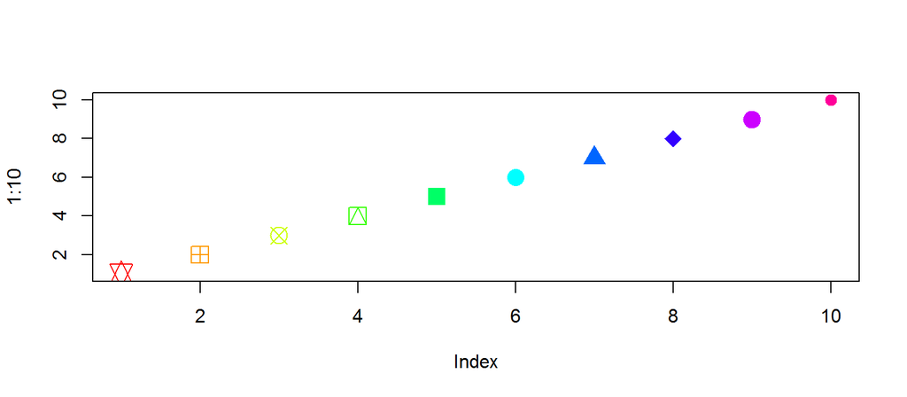

```r
plot(1:10, pch = 11:20, col = rainbow(10), cex = 2)
```

```r
dev.print(device = jpeg, file = "Test graphic.jpg", height = 500, width = 800)
```

# `ggplot` graphics

A different model of graphics has recently become popular. `ggplots` use a different ‘grammar’ of graphics, and can be great for quickly making visually-appealing graphics. Mastering the control of each element can take time.

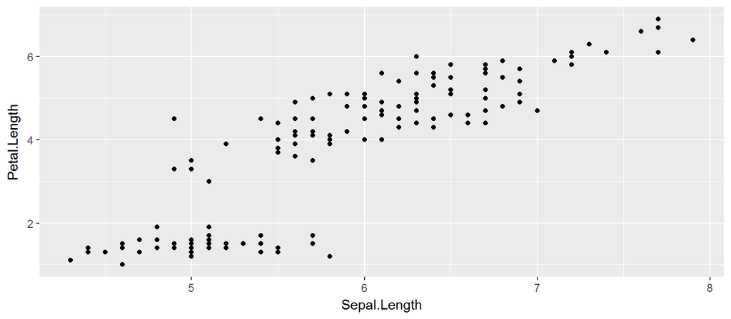

```r
library(ggplot2) # install.packages('ggplot2')
#       Dataset               x               y         type of plot
gp1 <- ggplot(iris) + aes(Sepal.Length, Petal.Length) + geom_point()

gp1
```

# ggplot graphics

You can use one basic graph data set and do different versions of it. Two ways of visualizing a factor grouping:

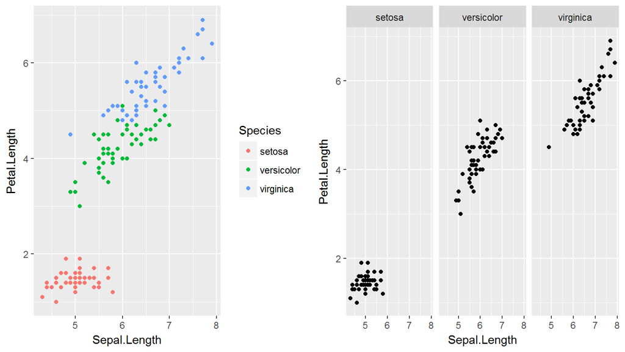

```r
gp1 + geom_point(aes(color = Species))
gp1 + facet_wrap(~ Species)
```

# Interactive

These can be made interactive in an HTML document using `plot.ly`. See https://plot.ly/r/ if interested in trying this! You will need to download several packages, so this code will not work for you immediately:

```r
library(plotly)
ggplotly(ex1)
```

[interactive chart not shown]

# Tables in R

Carrying out any analysis in R generates a lot of tables. A few options:

- Copy and paste
- Sink
- Save to text file

Simplest is copy and paste from the console window into Excel, then use text-to-columns. But not repeatable!

# Tables in R

You can ‘sink’ your output to a text file. First, set up all your analysis, then put `sink()` before and after your block of code.

```r
sink("Test Sink.txt")
with(iris, cor.test(Sepal.Width, Petal.Width))
table(iris$Species)
sink()
```

Or, more commonly, output a data frame to a text file directly:

```r
write.csv(iris[1:10,], file = "Iris Test.csv", row.names = F)
```

# R Markdown

A better way for writing a report is to take advantage of the relatively recent tool, R Markdown. A few resources:

http://rmarkdown.rstudio.com/ http://rmarkdown.rstudio.com/authoring_quick_tour.html

Go to File > New File … > R Markdown

Select HTML or Word as the default output, and then try clicking ‘knit’.

You may need to `install.packages("rmarkdown")`

# Homework review: Outliers

*Time permitting, we will go back to the Hubway data and examine the question of outliers*

We will review `tripduration` outliers from the Hubway data.